# Market Analysis: Problem Set 3

**Submission guidelines:**

1. Submission requires downloading and saving your ipynb file as .html file with the filename, studentID-studentName. For example, 407510073-束良鴻.
2. Removing all irrelevant code blocks.
3. Email the html file to your TA. (E-mail address: p4896p4896@gmail.com)
4. Failing to submit in a correct format will result in a reduction of **20 points**.
5. Deadline: 4/28 Thur. 1 p.m.
6. No late submission will be accepted.

## Preparation

直接執行下面一欄，把所有必備之套件正確引用。

```python
import pandas as pd
import numpy as np
import matplotlib.pyplot as plt
import seaborn as sns
%matplotlib inline
```

請把 **tipsdata.csv** 存成Pandas DataFrame Object，並命名為tips。

```python
tips = pd.read_csv('tipsdata.csv')
```

### 本資料為某間餐廳的小費資料，相關欄位有總消費金額(total_bill \$)，小費金額(tip \\$)，服務員之性別(sex)，有沒有抽菸(smoker)，星期幾(day)，時間(time)，以及顧客人數(size)。

```python
tips
```

|  | total_bill | tip | sex | smoker | day | time | size |
| --- | --- | --- | --- | --- | --- | --- | --- |
| 0 | 16.99 | 1.01 | Female | No | Sun | Dinner | 2 |
| 1 | 10.34 | 1.66 | Male | No | Sun | Dinner | 3 |
| 2 | 21.01 | 3.50 | Male | No | Sun | Dinner | 3 |
| 3 | 23.68 | 3.31 | Male | No | Sun | Dinner | 2 |
| 4 | 24.59 | 3.61 | Female | No | Sun | Dinner | 4 |
| ... | ... | ... | ... | ... | ... | ... | ... |
| 239 | 29.03 | 5.92 | Male | No | Sat | Dinner | 3 |
| 240 | 27.18 | 2.00 | Female | Yes | Sat | Dinner | 2 |
| 241 | 22.67 | 2.00 | Male | Yes | Sat | Dinner | 2 |
| 242 | 17.82 | 1.75 | Male | No | Sat | Dinner | 2 |
| 243 | 18.78 | 3.00 | Female | No | Thur | Dinner | 2 |

244 rows × 7 columns

## Q1 PANDAS資料分析 (45\%)

(a) 請印出前5行資料。(2 pts)

```python
tips.head(5)
```

|  | total_bill | tip | sex | smoker | day | time | size |
| --- | --- | --- | --- | --- | --- | --- | --- |
| 0 | 16.99 | 1.01 | Female | No | Sun | Dinner | 2 |
| 1 | 10.34 | 1.66 | Male | No | Sun | Dinner | 3 |
| 2 | 21.01 | 3.50 | Male | No | Sun | Dinner | 3 |
| 3 | 23.68 | 3.31 | Male | No | Sun | Dinner | 2 |
| 4 | 24.59 | 3.61 | Female | No | Sun | Dinner | 4 |

(b) 請問該資料檔共有幾個觀測值? (2 pts)

```python
len(tips)
```

```
244
```

(c) 請**隨機**印出11行資料。(你的結果應該會跟上面的不一樣。) (5 pts)

```python
tips.sample(11)
```

|  | total_bill | tip | sex | smoker | day | time | size |
| --- | --- | --- | --- | --- | --- | --- | --- |
| 120 | 11.69 | 2.31 | Male | No | Thur | Lunch | 2 |
| 185 | 20.69 | 5.00 | Male | No | Sun | Dinner | 5 |
| 28 | 21.70 | 4.30 | Male | No | Sat | Dinner | 2 |
| 223 | 15.98 | 3.00 | Female | No | Fri | Lunch | 3 |
| 243 | 18.78 | 3.00 | Female | No | Thur | Dinner | 2 |
| 86 | 13.03 | 2.00 | Male | No | Thur | Lunch | 2 |
| 211 | 25.89 | 5.16 | Male | Yes | Sat | Dinner | 4 |
| 162 | 16.21 | 2.00 | Female | No | Sun | Dinner | 3 |
| 127 | 14.52 | 2.00 | Female | No | Thur | Lunch | 2 |
| 138 | 16.00 | 2.00 | Male | Yes | Thur | Lunch | 2 |
| 121 | 13.42 | 1.68 | Female | No | Thur | Lunch | 2 |

(d) 請問午餐(Lunch)與晚餐(Dinner)的平均消費金額為多少? (8 pts)

```python
total_average = tips['total_bill'].mean()
total_average
```

```
19.785942622950824
```

```python
lunch_average = tips[tips['time']=='Lunch']['total_bill'].mean()
lunch_average
```

```
17.16867647058823
```

```python
dinner_average = tips[tips['time']=='Dinner']['total_bill'].mean()
dinner_average
```

```
20.7971590909091
```

(e) 請問顧客人數為4人時，所給的小費平均金額為多少? (8 pts)

```python
tips[tips['size']==4]['tip'].mean()
```

```
4.135405405405407
```

(f) 請問有幾個觀測值是有抽菸的? (10 pts)

```python
smoker = len(tips[tips['smoker']=='Yes'])
smoker
```

```
93
```

(g) 請創建一個新欄位，名稱為**percent**，來計算小費佔總消費金額之比例。並找出最高的比例為何? (10 pts)

```python
tips['percent'] = tips.tip / tips.total_bill
tips['percent'].max()
```

```
0.710344827586207
```

## Q2 視覺化分析 (25\%)

(a) 請用Seaborn，繪製出消費金額(total_bill \$)，小費金額(tip \\$)，顧客人數(size)的pairplot。(只有三個數值欄位，所以僅有3$\times$3) (5 pts)

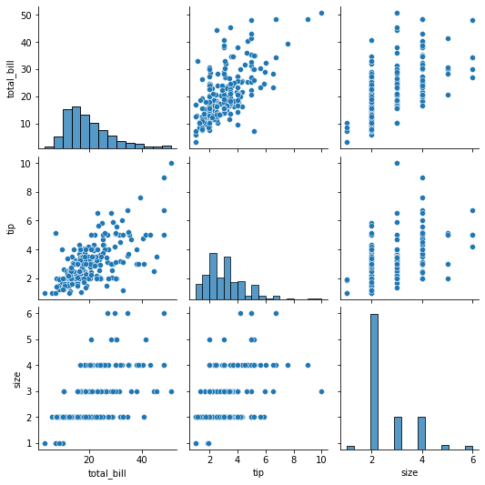

```python
sns.pairplot(tips[['total_bill','tip','size']])
```

(b) 請試圖畫出一個joint plot，x軸用total_bill，y軸用tip。 (5 pts)

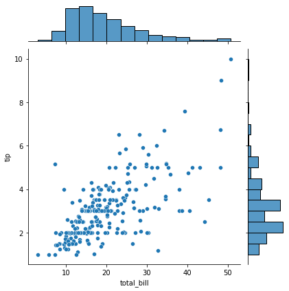

```python
sns.jointplot(x = 'total_bill',y ='tip',data = tips)
```

(c) 請畫出total_bill的直方圖。 (5 pts)

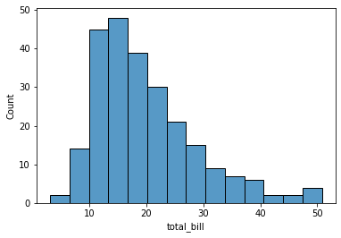

```python
sns.histplot(tips['total_bill'])
```

(d) 畫出**total_bill**與**tip**的散布圖(scatter plot)，並依照顧客人數決定圓點大小，最後把透明度調整為0.3。 (10 pts)

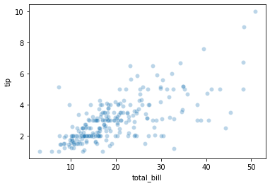

```python
sns.scatterplot(x = 'total_bill', y = 'tip', data = tips, alpha = 0.3)
```

## Q3 Linear Regression (40\%)

在進行迴歸分析之前，我們要先把一些質性的變數轉換為虛擬變數(dummy variables)，並把它存為新的DataFrame名為tip_lm。請先執行下面程式碼。

```python
tip_lm = pd.concat([tips, pd.get_dummies(tips['sex']), pd.get_dummies(tips['time']), pd.get_dummies(tips['smoker'])], axis=1)
tip_lm
```

|  | total_bill | tip | sex | smoker | day | time | size | percent | Female | Male | Dinner | Lunch | No | Yes |
| --- | --- | --- | --- | --- | --- | --- | --- | --- | --- | --- | --- | --- | --- | --- |
| 0 | 16.99 | 1.01 | Female | No | Sun | Dinner | 2 | 0.059447 | 1 | 0 | 1 | 0 | 1 | 0 |
| 1 | 10.34 | 1.66 | Male | No | Sun | Dinner | 3 | 0.160542 | 0 | 1 | 1 | 0 | 1 | 0 |
| 2 | 21.01 | 3.50 | Male | No | Sun | Dinner | 3 | 0.166587 | 0 | 1 | 1 | 0 | 1 | 0 |
| 3 | 23.68 | 3.31 | Male | No | Sun | Dinner | 2 | 0.139780 | 0 | 1 | 1 | 0 | 1 | 0 |
| 4 | 24.59 | 3.61 | Female | No | Sun | Dinner | 4 | 0.146808 | 1 | 0 | 1 | 0 | 1 | 0 |
| ... | ... | ... | ... | ... | ... | ... | ... | ... | ... | ... | ... | ... | ... | ... |
| 239 | 29.03 | 5.92 | Male | No | Sat | Dinner | 3 | 0.203927 | 0 | 1 | 1 | 0 | 1 | 0 |
| 240 | 27.18 | 2.00 | Female | Yes | Sat | Dinner | 2 | 0.073584 | 1 | 0 | 1 | 0 | 0 | 1 |
| 241 | 22.67 | 2.00 | Male | Yes | Sat | Dinner | 2 | 0.088222 | 0 | 1 | 1 | 0 | 0 | 1 |
| 242 | 17.82 | 1.75 | Male | No | Sat | Dinner | 2 | 0.098204 | 0 | 1 | 1 | 0 | 1 | 0 |
| 243 | 18.78 | 3.00 | Female | No | Thur | Dinner | 2 | 0.159744 | 1 | 0 | 1 | 0 | 1 | 0 |

244 rows × 14 columns

從上面新的DataFrame看來，我們已經把依序把三個質性的變數，轉成兩個虛擬變數sex(Female、Male)，time(Dinner、Lunch)，somoker(Yes、No)。 接著定義你的X變數與Y變數，並且引用線性模型的模組。 (這一題不需使用train_test_split，我們把所有樣本都拿來估計與預測。)

```python
from sklearn.linear_model import LinearRegression
Y = tip_lm['tip']
X = tip_lm[['total_bill', 'Female', 'size', 'Dinner', 'Yes']]
```

(a) 請用上面之X與Y來訓練或估計一個線性迴歸模型。並該模型之係數為何? (10 pts)

```python
lm = LinearRegression()
lm.fit(X,Y)
print('係數: ', lm.coef_)
```

```
係數:  [ 0.09406811  0.02811064  0.18027415  0.00494742 -0.08390208]
```

(b) 請用這個模型來預測所有244個樣本的小費金額，並把它存在predictions裡面，再來把predictions給印出來。 (10 pts)

```python
predictions = lm.predict(X)
print(predictions)
```

```
[2.68401793 2.21062852 3.21433525 3.28522295 3.75948387 3.79722091
 1.88266743 3.94678921 2.47247448 2.44801677 2.0237696  4.76319061
 2.50822036 3.15191368 2.48083082 3.08767992 2.23779847 2.77033377
 2.86241072 3.18047073 2.74339064 2.9944427  2.56925484 5.1264033
 2.92212004 3.09359145 2.31538074 2.25141442 3.09896809 2.9342391
 1.95604056 3.14438823 2.50246648 3.39261825 2.7302211  3.50124298
 2.77221513 2.858648   2.99609723 4.17947406 2.74681674 2.70011931
 2.36899956 1.96826941 4.27790895 2.77819584 3.14882419 4.46604517
 3.9236088  2.75467881 2.23730421 2.0537616  4.72085996 1.99272712
 3.8226193  2.89107757 4.90986519 3.57013953 2.03111358 5.95890608
 2.88242998 2.27286862 2.0104186  3.05484206 2.89262231 3.12685191
 2.63322115 1.11041361 2.96068797 2.38575036 2.18838879 2.87181753
 3.5285681  3.37994048 2.471424   2.04634594 2.65948856 3.97194359
 3.19373287 2.67918031 2.79752467 2.6199174  1.84784504 4.04298644
 2.55595109 4.7177939  2.27845016 2.77230774 3.37716569 3.0432239
 3.69894117 3.1732819  1.5427903  2.53709022 3.22585025 5.11305231
 3.53996606 2.10542739 2.95015901 2.22977876 2.06957171 2.4486662
 5.34939009 3.11090569 3.0537056  2.41867419 2.9012436  3.34524508
 2.77349243 2.34801332 2.37464365 1.58752039 4.8191372  3.31062134
 3.684566   2.71411973 4.23369694 2.0826787  2.25011994 3.70656172
 2.1523989  2.34324736 2.39415394 2.55312904 2.25482334 4.60517962
 1.85420299 2.44672228 2.15134842 3.37965111 2.84756223 2.98761392
 2.13159412 2.23412836 2.79853702 1.88137294 2.0525769  2.41191708
 2.47393037 2.31878966 2.72422321 5.00037547 5.4682306  4.34649231
 2.62639237 1.86632205 3.01455705 2.19744179 1.97272881 1.7591942
 2.38122841 2.29280439 2.86157984 3.72761051 3.27796495 4.43455629
 6.31004757 3.7980518  2.34537274 2.96942155 3.44070278 2.24859238
 2.79091896 2.3567707  2.64903127 3.54451431 3.01054407 4.40113818
 1.99807995 2.00184267 5.93366284 2.46100484 1.65578182 3.96985733
 2.55601363 4.06862884 2.65666651 2.33589426 1.90495252 4.23136667
 4.59379634 3.16839703 5.42005096 3.51389444 4.78824988 3.54478176
 3.14819631 4.37992511 2.88950901 3.32703552 2.44971667 2.86044051
 3.64413765 2.42501495 2.52848987 1.7638976  1.94150487 5.41277577
 2.21983668 2.23970077 2.9091291  2.19537897 2.21983668 2.53966825
 3.26060721 2.72652717 3.65533322 4.97759423 3.25682105 2.20220775
 3.98174956 3.7697597  5.96455016 2.25018248 3.83207147 2.21537728
 4.16262778 2.06403742 1.7018752  4.1976598  2.11270883 2.25934528
 1.59567084 2.76433588 2.23123464 2.5274394  1.94609848 3.34193126
 2.30691461 3.08268526 3.59291165 2.62999082 2.14982086 2.07080365
 2.43466577 2.00495597 2.15904621 4.06204407 4.63653528 3.96876149
 3.55866989 3.10631208 2.73398383 2.85239985]
```

(c) 請將實際小費減去預測小費後，計算出誤差項後，畫出該之直方圖與分布線。 (10 pts)

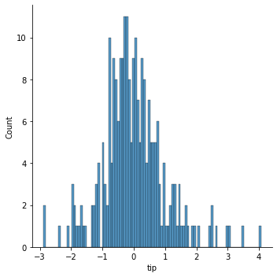

```python
sns.displot((Y-predictions), bins = 100)
```

(d) 請計算出該樣本之MSE(mean squared errors)。 (10 pts)

```python
from sklearn.metrics import mean_squared_error #函數解
mean_squared_error(Y,predictions)
```

```
1.0128505576413998
```

```python
sum((Y - predictions)**2)/len(tips) #公式解
```

```
1.0128505576413998
```